# Sharing power, simulation, and modeling noise

Peter Ralph

27 November 2018 – Advanced Biological Statistics

# Baseball

## Baseball

We have a dataset of batting averages of baseball players, having

1. name
2. position
3. number of at bats
4. number of hits

```r
batting <- read.csv("BattingAverage.csv", header=TRUE)
head(batting)
```

```
##          Player     PriPos Hits AtBats PlayerNumber PriPosNumber
## 1 Fernando Abad    Pitcher    1      7            1            1
## 2   Bobby Abreu Left Field   53    219            2            7
## 3    Tony Abreu   2nd Base   18     70            3            4
## 4 Dustin Ackley   2nd Base  137    607            4            4
## 5    Matt Adams   1st Base   21     86            5            3
## 6 Nathan Adcock    Pitcher    0      1            6            1
```

The *overall* batting average of the 948 players is 0.2546597.

Here is the average by position.

```r
batting %>% group_by(PriPos) %>%
    summarise(num=n(), BatAvg=sum(Hits)/sum(AtBats)) %>%
    select(PriPos, num, BatAvg)
```

```
## # A tibble: 9 x 3
##   PriPos         num BatAvg
##   <fct>        <int>  <dbl>
## 1 1st Base        81  0.259
## 2 2nd Base        72  0.256
## 3 3rd Base        75  0.265
## 4 Catcher        103  0.247
## 5 Center Field    67  0.264
## 6 Left Field     103  0.259
## 7 Pitcher        324  0.129
## 8 Right Field     60  0.264
## 9 Shortstop       63  0.255
```

## Questions?

1. What’s the overall batting average?
2. Do some positions tend to be better batters?
3. How much variation is there?

## Everyone is the same

```r
first_model <- "
data {
    int N;
    int hits[N];
    int at_bats[N];
}
parameters {
    real<lower=0, upper=1> theta;
}
model {
    hits ~ binomial(at_bats, theta);
    theta ~ beta(1, 1);
} "
first_fit <- stan(model_code=first_model, chains=3, iter=1000,
                  data=list(N=nrow(batting),
                            hits=batting$Hits,
                            at_bats=batting$AtBats))
```

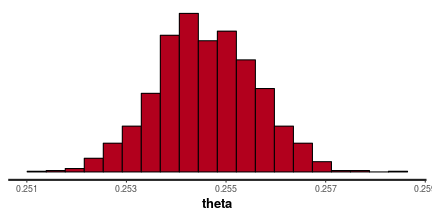

```r
stan_hist(first_fit, bins=20)
```

```r
pos_model <- "
data {
    int N;
    int hits[N];
    int at_bats[N];
    int npos; // number of positions
    int position[N];
}
parameters {
    real<lower=0, upper=1> theta[npos];
}
model {
    real theta_vec[N];
    for (k in 1:N) {
        theta_vec[k] = theta[position[k]];
    }
    hits ~ binomial(at_bats, theta_vec);
    theta ~ beta(1, 1);
} "
pos_fit <- stan(model_code=pos_model, chains=3, iter=1000,
                  data=list(N=nrow(batting),
                            hits=batting$Hits,
                            at_bats=batting$AtBats,
                            npos=nlevels(batting$PriPos),
                            position=as.numeric(batting$PriPos)))
```

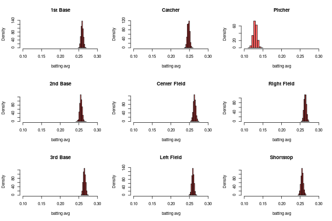

```r
theta_samples <- extract(pos_fit)$theta
layout(matrix(1:9, nrow=3))
for (k in 1:ncol(theta_samples)) {
    hist(theta_samples[,k], main=levels(batting$PriPos)[k], xlim=c(0.1, 0.3),
         col=adjustcolor('red',0.6), xlab='batting avg', freq=FALSE)
}
```

## Your turn : Every individual different.

$$\begin{aligned}
Z_i &\sim \Binom(N_i, \theta_i) \\
\theta_i &\sim \Beta(\alpha_{p_i}, \beta_{p_i}) \\
\alpha_p &= \mu_p \kappa_p \\
\beta_p &= (1-\mu_p) \kappa_p \\
\mu_p &\sim \Beta(1, 1) \\
\kappa_p &\sim \Gam(0.1, 0.1) .
\end{aligned}$$

Variable types in Stan:

```
int x;       // an integer
int y[10];   // ten integers
real z;      // a number
real z[2,5]; // a 2x5 array of numbers

vector u[10];      // length 10 vector
matrix v[10,10];   // 10x10 matrix
vector[10] w[10];  // ten length 10 vectors
```

- don’t forget the `;`
- make sure R types match
- read the error messages

# Stochastic minute

## Exponential, and Gamma

If $T \sim \Exp(\text{rate}=\lambda)$, then

$$\begin{aligned}
\P\{ T \in dt \} = \lambda e^{-\lambda t} dt .
\end{aligned}$$

1. $T$ can be any nonnegative real number.
2. $T$ is *memoryless*:
   $$\begin{aligned}
   \P\{ T > x + y \given T > x \} = \P\{ T > y \} .
   \end{aligned}$$
3. A machine produces $n$ widgets per second; each widget has probability $\lambda/n$ of being broken. The time until the first broken widget appears (in seconds) is approximately $\sim \Exp(\lambda)$.

If $S \sim \Gam(\text{shape}=\alpha, \text{rate}=\lambda)$, then

$$\begin{aligned}
\P\{ S \in dt \} = \frac{\alpha^\lambda}{\Gamma(\alpha)} t^{\alpha - 1} e^{-\lambda t} dt .
\end{aligned}$$

1. If $T_1, \ldots, T_k$ are independent $\Exp(\lambda)$, then $S = T_1 + \cdots + T_k$ is $\Gam(k, \lambda)$.
2. A machine produces $n$ widgets per second; each widget has probability $\lambda/n$ of being broken. The time until the $k^\text{th}$ broken widget appears (in seconds) is approximately $\sim \Gam(k, \lambda)$.

# Back to baseball

## The model

$$\begin{aligned}
Z_i &\sim \Binom(N_i, \theta_i) \\
\theta_i &\sim \Beta(\mu_{p_i} \kappa_{p_i}, (1-\mu_{p_i})\kappa_{p_i}) \\
\mu &\sim \Beta(1, 1) \\
\kappa_p &\sim \Gam(0.1, 0.1) .
\end{aligned}$$

```r
pos_model <- "
data {
    int N;   // number of players
    int hits[N];
    int at_bats[N];
    int npos; // number of positions
    int position[N];
}
parameters {
    real<lower=0, upper=1> theta[N];
    real<lower=0, upper=1> mu[npos];
    real<lower=0> kappa[npos];
}
model {
    real alpha;
    real beta;
    hits ~ binomial(at_bats, theta);
    for (i in 1:N) {
        alpha = mu[position[i]] * kappa[position[i]];
        beta = (1 - mu[position[i]]) * kappa[position[i]];
        theta[i] ~ beta(alpha, beta);
    }
    mu ~ beta(1,1);
    kappa ~ gamma(0.1,0.1);
}"
```

```r
batting <- read.csv("BattingAverage.csv", header=TRUE)
system.time(pos_fit <- stan(model_code=pos_model, chains=3, iter=100,
                            data=list(N=nrow(batting),
                                      hits=batting$Hits,
                                      at_bats=batting$AtBats,
                                      npos=nlevels(batting$PriPos),
                                      position=as.numeric(batting$PriPos))))
```

```
##    user  system elapsed
##  83.672   0.968  68.372
```

## Diagnostics

```r
print(pos_fit, pars=c("mu", "kappa"))
```

```
## Inference for Stan model: db775bca82d7fc39d379745fb39b0819.
## 3 chains, each with iter=100; warmup=50; thin=1;
## post-warmup draws per chain=50, total post-warmup draws=150.
##
##            mean se_mean    sd  2.5%    25%    50%    75%  97.5% n_eff Rhat
## mu[1]      0.25    0.00  0.01  0.24   0.25   0.25   0.26   0.26   150 1.00
## mu[2]      0.25    0.00  0.01  0.24   0.25   0.25   0.25   0.26   150 0.99
## mu[3]      0.26    0.00  0.01  0.24   0.25   0.25   0.26   0.27   102 1.03
## mu[4]      0.24    0.00  0.01  0.23   0.24   0.24   0.24   0.25   150 0.99
## mu[5]      0.26    0.00  0.01  0.25   0.25   0.26   0.26   0.27   150 1.00
## mu[6]      0.25    0.00  0.01  0.24   0.25   0.25   0.25   0.26   135 1.00
## mu[7]      0.13    0.00  0.01  0.12   0.13   0.13   0.13   0.14    49 1.02
## mu[8]      0.26    0.00  0.01  0.24   0.25   0.26   0.26   0.27   150 0.99
## mu[9]      0.25    0.00  0.01  0.23   0.24   0.25   0.25   0.26   150 0.99
## kappa[1] 114.88    2.30 26.14 71.55  97.48 111.02 129.46 171.96   129 1.02
## kappa[2] 106.91    2.10 25.73 64.27  86.57 106.71 123.82 166.11   150 1.01
## kappa[3]  98.36    2.13 18.60 67.26  85.47  97.46 109.55 139.78    76 1.03
## kappa[4]  95.51    1.87 20.90 59.52  81.30  92.11 107.85 136.19   125 0.99
## kappa[5]  99.94    1.96 19.88 64.93  83.72 100.08 112.14 142.69   103 1.02
## kappa[6] 104.78    1.91 19.86 69.61  90.25 104.28 116.12 148.35   108 1.00
## kappa[7]  54.50    2.25 10.81 35.97  46.05  53.83  62.41  76.05    23 1.10
## kappa[8] 121.88    2.41 29.57 73.44 102.79 119.24 139.14 184.28   150 1.00
## kappa[9]  93.11    2.94 23.34 58.17  76.77  90.33 108.38 144.98    63 1.02
##
## Samples were drawn using NUTS(diag_e) at Mon Nov 26 22:03:38 2018.
## For each parameter, n_eff is a crude measure of effective sample size,
## and Rhat is the potential scale reduction factor on split chains (at
## convergence, Rhat=1).
```

Is it mixing?

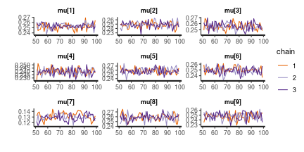

```r
stan_trace(pos_fit, pars="mu")
```

## Run longer!

```r
system.time(pos_fit <- stan(model_code=pos_model, chains=3, iter=1000,
                            control=list(max_treedepth=15),
                            data=list(N=nrow(batting),
                                      hits=batting$Hits,
                                      at_bats=batting$AtBats,
                                      npos=nlevels(batting$PriPos),
                                      position=as.numeric(batting$PriPos))))
```

```
## recompiling to avoid crashing R session
```

```
##    user  system elapsed
## 1453.37    1.50  595.30
```

```r
print(pos_fit, pars=c("mu", "kappa"))
```

```
## Inference for Stan model: db775bca82d7fc39d379745fb39b0819.
## 3 chains, each with iter=1000; warmup=500; thin=1;
## post-warmup draws per chain=500, total post-warmup draws=1500.
##
##            mean se_mean    sd  2.5%   25%    50%    75%  97.5% n_eff Rhat
## mu[1]      0.25    0.00  0.01  0.24  0.25   0.25   0.26   0.26  1500 1.00
## mu[2]      0.25    0.00  0.01  0.24  0.24   0.25   0.25   0.26  1243 1.00
## mu[3]      0.26    0.00  0.01  0.24  0.25   0.26   0.26   0.27  1500 1.00
## mu[4]      0.24    0.00  0.01  0.23  0.24   0.24   0.24   0.25  1240 1.00
## mu[5]      0.26    0.00  0.01  0.24  0.25   0.26   0.26   0.27  1500 1.00
## mu[6]      0.25    0.00  0.01  0.24  0.25   0.25   0.25   0.26  1324 1.00
## mu[7]      0.13    0.00  0.01  0.12  0.13   0.13   0.13   0.14   528 1.01
## mu[8]      0.26    0.00  0.01  0.24  0.25   0.26   0.26   0.27  1500 1.00
## mu[9]      0.25    0.00  0.01  0.23  0.24   0.25   0.25   0.26  1500 1.00
## kappa[1] 111.28    0.72 22.73 71.99 95.06 109.19 124.41 162.22  1010 1.00
## kappa[2] 104.40    0.81 23.53 63.40 88.48 101.62 118.60 157.52   840 1.01
## kappa[3]  97.66    0.63 20.98 61.33 83.25  95.52 109.80 145.61  1109 1.00
## kappa[4]  95.48    0.74 19.70 62.44 81.45  94.06 107.42 137.05   714 1.01
## kappa[5] 102.00    0.69 21.93 65.47 85.96 100.75 115.39 151.21  1018 1.01
## kappa[6] 106.63    0.78 21.16 71.49 91.07 104.66 120.64 152.70   745 1.00
## kappa[7]  52.60    1.86 12.15 33.52 43.69  51.08  59.35  80.01    43 1.06
## kappa[8] 117.48    0.80 27.68 72.36 97.72 114.95 134.28 181.78  1207 1.00
## kappa[9]  93.55    0.69 22.33 56.79 78.05  91.18 106.90 142.96  1056 1.00
##
## Samples were drawn using NUTS(diag_e) at Mon Nov 26 22:13:36 2018.
## For each parameter, n_eff is a crude measure of effective sample size,
## and Rhat is the potential scale reduction factor on split chains (at
## convergence, Rhat=1).
```

Is it mixing?

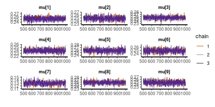

```r
stan_trace(pos_fit, pars="mu")
```

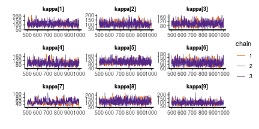

```r
stan_trace(pos_fit, pars="kappa")
```

## Let’s look at the results!

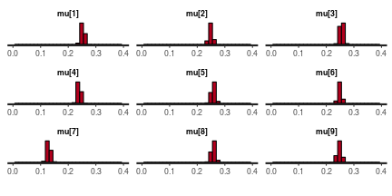

```r
stan_hist(pos_fit, pars="mu", bins=30) + xlim(0, 0.4)
```

With labels: position means $\mu_p$:

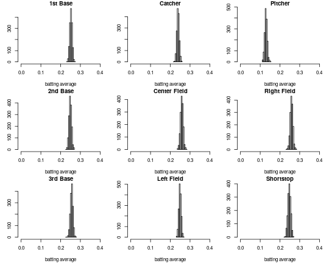

Position “concentrations”, $\kappa_p$:

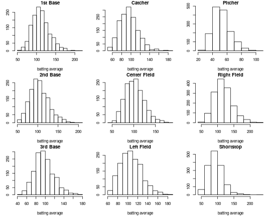

# Simulation

## Wouldn’t it be nice if we knew the truth?

**Discuss:**

Write down (on whiteboards) a procedure to simulate data that looks like the baseball data.

```r
batting$post_mean <- colMeans(param_samples$theta)
batting$fake_hits <- rbinom(nrow(batting),
                            size=batting$AtBats,
                            prob=batting$post_mean)
```

*Option 1:* By simulating draws from the posterior mean on $\theta$, we can check that our model is accurately describing the data. Here is the real data against data simulated under the posterior mean $\theta$ values. They look similar, which is good.

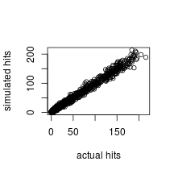

**But** if we want to know if we’re accurately estimating $\mu$ and $\kappa$, then we have to start with them, and *simulate* $\theta$.

```r
post_mean_mu <- colMeans(param_samples$mu)
post_mean_kappa <- colMeans(param_samples$kappa)
names(post_mean_mu) <- names(post_mean_kappa) <- levels(batting$PriPos)
batting$sim_theta <- rbeta(nrow(batting),
                           shape1=post_mean_mu[batting$PriPos] *
                                   post_mean_kappa[batting$PriPos],
                           shape2=(1-post_mean_mu[batting$PriPos]) *
                                   post_mean_kappa[batting$PriPos])
batting$sim_theta_hits <- rbinom(nrow(batting),
                                 size=batting$AtBats,
                                 prob=batting$sim_theta)
```

Fit the model to the *simulated* data:

```r
sim_fit <- stan(model_code=pos_model, chains=3, iter=1000, control=list(max_treedepth=13),
                data=list(N=nrow(batting),
                          hits=batting$sim_theta_hits,
                          at_bats=batting$AtBats,
                          npos=nlevels(batting$PriPos),
                          position=as.numeric(batting$PriPos)))
```

```
## recompiling to avoid crashing R session
```

Can we estimate $\mu$ and $\kappa$?

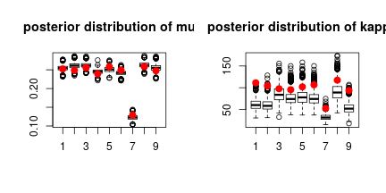

```r
sim_samples <- extract(sim_fit)
layout(t(1:2))
boxplot(sim_samples$mu, main="posterior distribution of mu")
points(1:9, post_mean_mu, col='red', pch=20, cex=2)
boxplot(sim_samples$kappa, main="posterior distribution of kappa")
points(1:9, post_mean_kappa, col='red', pch=20, cex=2)
```

## General questions with simulated data

1. Does my statistical inference method work?
2. Do the credible intervals contain the true value?

   (i.e., Is the method “well-calibrated”?)

   *They usually should.*
3. How wide are credible intervals, typically?

   This is (one kind of) **statistical power.**

# Posterior predictive sampling

## How to choose parameter values for simulation?

It depends, but one good choice is *from the posterior distribution* - then you can see how the model behaves with data close to the real data.

This is known as **posterior predictive sampling**.

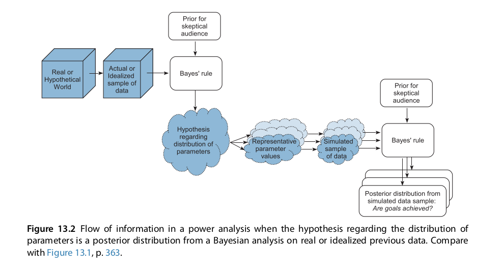

Kruschke figure 13.2: posterior predictive sampilng

# Sharing power // Shrinkage

## Example

Suppose that I have a large pot of coins that are all similar to each other. I flip each one ten times, and record the number of Heads. What is *each coin’s* probability of Heads?

- Treated *separately*, we would be very uncertain about each coin.
- Together, they should tell us very accurately what are *likely* values of $\theta$.
- This information can improve the estimate of each separate $\theta$.
- The more similar the coins are, the more information we gain.

## Shrinkage and baseball

Some players were at bat very few times. How does the information about their position affect our inference about their batting averages?

```r
batting$post_med <- colMedians(param_samples$theta)
batting$post_Q1 <- colQuantiles(param_samples$theta, probs=0.25)
batting$post_Q3 <- colQuantiles(param_samples$theta, probs=0.75)
pos_means <- colMeans(param_samples$mu)
names(pos_means) <- levels(batting$PriPos)
pos_means
```

```
##     1st Base     2nd Base     3rd Base      Catcher Center Field
##    0.2524128    0.2488493    0.2555532    0.2392593    0.2582094
##   Left Field      Pitcher  Right Field    Shortstop
##    0.2491433    0.1290069    0.2584937    0.2473966
```

Pitchers had posterior mean $\mu$ of 0.1290069

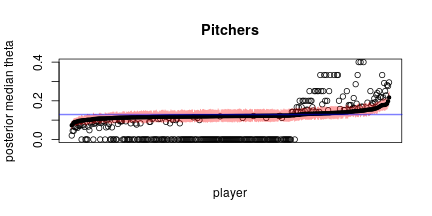

```r
with(subset(batting[order(batting$post_med),], PriPos=="Pitcher"), {
     plot(Hits / AtBats, main="Pitchers", xaxt='n', ylim=c(0, 0.4),
         xlab='player', ylab="posterior median theta");
     segments(x0=seq_along(Hits), y0=post_Q1, y1=post_Q3,
         col=adjustcolor('red',0.5));
     points(post_med, pch=20) })
abline(h=pos_means["Pitcher"], lwd=2, col=adjustcolor("blue", 0.5))
```

Catchers had posterior mean $\mu$ of 0.2392593

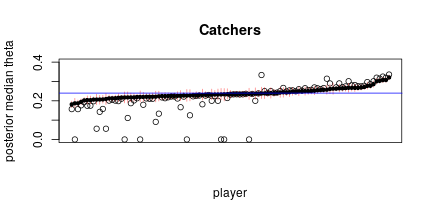

```r
with(subset(batting[order(batting$post_med),], PriPos=="Catcher"), {
     plot(Hits / AtBats, main="Catchers", xaxt='n', ylim=c(0, 0.4),
         xlab='player', ylab="posterior median theta");
     segments(x0=seq_along(Hits), y0=post_Q1, y1=post_Q3,
         col=adjustcolor('red',0.5));
     points(post_med, pch=20) })
abline(h=pos_means["Catcher"], lwd=2, col=adjustcolor("blue", 0.5))
```

## Is shrinkage here a good idea?

With *simulated data*, compare median absolute error for

- posterior mean $\theta_i$
- empirical batting average

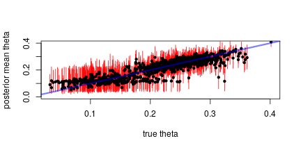

```r
post_sim_theta <- colMeans(sim_samples$theta)
plot(batting$sim_theta, post_sim_theta, type='n', xlab="true theta", ylab="posterior mean theta", ylim=c(0,0.4))
segments(x0=batting$sim_theta,  col='red',
         y0=colQuantiles(sim_samples$theta, probs=0.05),
         y1=colQuantiles(sim_samples$theta, probs=0.95))
points(batting$sim_theta, post_sim_theta, pch=20)
abline(0, 1, lwd=3, col=adjustcolor('blue', 0.5))
```

Did we do better?

The mean absolute difference between the *truth* and

- posterior mean: 0.0255297
- empirical batting average (hits/at bats): 0.0862214

# Logistic regression, a.k.a. metric predictors

## Motivation

There’s a good bit more information available about the baseball players.

```r
batplus <- read.csv("BattingAveragePlus.csv")
head(batplus)
```

```
##             Player     PriPos Hits AtBats PlayerNumber PriPosNumber
## 1 Aaron Cunningham Left Field   17     97          198            7
## 2     Aaron Harang    Pitcher    4     56          360            1
## 3       Aaron Hill   2nd Base  184    609          394            4
## 4     Aaron Laffey    Pitcher    0      1          482            1
## 5       Aaron Loup    Pitcher    0      1          522            1
## 6        Adam Dunn   1st Base  110    539          242            3
##    playerID weight height bats birthYear      debut  finalGame
## 1 cunniaa01    215     71    R      1986 2008-08-31 2012-07-24
## 2 haranaa01    260     79    R      1978 2002-05-25 2015-10-03
## 3  hillaa01    200     71    R      1982 2005-05-20 2016-10-01
## 4 laffeaa01    190     71    L      1985 2007-08-04 2015-07-31
## 5  loupaa01    210     71    L      1987 2012-07-14 2016-09-30
## 6  dunnad01    285     78    L      1979 2001-07-20 2014-09-28
```

Is batting average predicted by weight and height?

1. Each player has their own batting avg, $\theta_i$.
2. Batting averages tend to be different for different positions.
3. After accounting for position ($p_i$), $\theta$ varies with height ($h_i$) and/or weight ($w_i$).

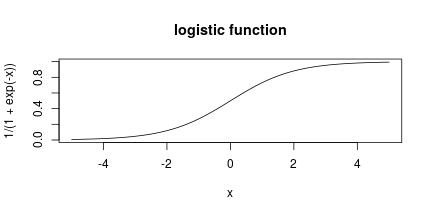

$$\begin{aligned}
Z_i &\sim \Binom(N_i, \theta_i) \\
\theta_i &= \Beta(\mu_i \kappa_{p_i}, (1-\mu_i) \kappa_{p_i}) \\
\mu_i &= \logistic(\gamma_{p_i} + \alpha_h h_i + \alpha_w w_i) \\
\kappa_p &\sim \Gam(0.1, 0.1) \\
\gamma_{p} &\sim \Normal(0, \sigma_\gamma) \\
\alpha_h &\sim \Normal(0, \sigma_h) \\
\alpha_w &\sim \Normal(0, \sigma_w) \\
\sigma_\gamma, \sigma_h, \sigma_w &\sim \Normal^+(0, 20)
\end{aligned}$$

## Stan

```r
logistic_model <- "
data {
    int N;   // number of players
    int hits[N];
    int at_bats[N];
    int npos; // number of positions
    int position[N];
    vector[N] height;
    vector[N] weight;
}
parameters {
    real<lower=0, upper=1> theta[N];
    vector[npos] gamma;
    real alpha_w;
    real alpha_h;
    vector<lower=0>[npos] kappa;
}
model {
    vector[N] mu;
    mu = inv_logit(gamma[position] + alpha_h * height + alpha_w * weight);
    theta ~ beta(mu .* kappa[position], (1-mu) .* kappa[position]);
    hits ~ binomial(at_bats, theta);
    kappa ~ gamma(0.1, 0.1);
    gamma ~ normal(0, 5);
    alpha_h ~ normal(0, 5);
    alpha_w ~ normal(0, 5);
} "
```

$$\begin{aligned}
Z_i &\sim \Binom(N_i, \theta_i) \\
\theta_i &= \Beta(\mu_i \kappa_{p_i}, (1-\mu_i) \kappa_{p_i}) \\
\mu_i &= \logistic(\gamma_{p_i} + \alpha_h h_i + \alpha_w w_i) \\
\kappa_p &\sim \Gam(0.1, 0.1) \\
\gamma_{p} &\sim \Normal(0, 5) \\
\alpha_h &\sim \Normal(0, 5) \\
\alpha_w &\sim \Normal(0, 5)
\end{aligned}$$

## New features

```r
logistic_model <- "
data {
    int N;   // number of players
    int hits[N];
    int at_bats[N];
    int npos; // number of positions
    int position[N];
    vector[N] height;
    vector[N] weight;
}
parameters {
    real<lower=0, upper=1> theta[N];
    vector[npos] gamma;
    real alpha_w;
    real alpha_h;
    vector<lower=0>[npos] kappa;
}
model {
    vector[N] mu;
    mu = inv_logit(gamma[position] + alpha_h * height + alpha_w * weight);
    theta ~ beta(mu .* kappa[position], (1-mu) .* kappa[position]);
    hits ~ binomial(at_bats, theta);
    kappa ~ gamma(0.1, 0.1);
    gamma ~ normal(0, 5);
    alpha_h ~ normal(0, 5);
    alpha_w ~ normal(0, 5);
} "
```

1. `vector[N] height;` instead of `real height[N];`: to allow `alpha_h * height`.
2. we will *center* and *scale* height and weight before passing to Stan
3. `x .* y` for component-wise multiplication

```r
scaled_height <- (batplus$height - mean(batplus$height))/sd(batplus$height)
scaled_weight <- (batplus$weight - mean(batplus$weight))/sd(batplus$weight)
system.time(logistic_fit <- stan(model_code=logistic_model, chains=3, iter=1000,
                               control=list(adapt_delta=0.9, max_treedepth=12),
                               data=list(N=nrow(batplus),
                                      hits=batplus$Hits,
                                      at_bats=batplus$AtBats,
                                      npos=nlevels(batplus$PriPos),
                                      position=as.numeric(batplus$PriPos),
                                      height=scaled_height,
                                      weight=scaled_weight) ))
```

```
##    user  system elapsed
## 416.875   1.121 174.229
```

```r
logistic_summary <- rstan::summary(logistic_fit)$summary
print(logistic_summary)
```

[output not shown]

[output cut: 2669 more lines]

```
## gamma[7]    615.5653 1.0016183
## gamma[8]   1500.0000 1.0002329
## gamma[9]   1500.0000 0.9995473
## alpha_w    1500.0000 1.0065264
## alpha_h    1500.0000 1.0021712
## kappa[1]    995.4217 0.9995813
## kappa[2]   1500.0000 1.0003780
## kappa[3]   1500.0000 0.9997823
## kappa[4]   1029.5624 1.0002799
## kappa[5]   1500.0000 1.0004720
## kappa[6]    802.4592 0.9995102
## kappa[7]    128.0893 1.0214134
## kappa[8]   1500.0000 0.9989129
## kappa[9]   1500.0000 1.0005137
## lp__        137.5094 1.0126180
```

## Pitchers still don’t bat well

```
## ci_level: 0.8 (80% intervals)
```

```
## outer_level: 0.95 (95% intervals)
```

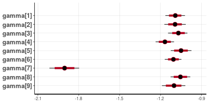

```r
stan_plot(logistic_fit, pars="gamma")
```

Recall the *mean* of $\theta_i$ is
$$\begin{aligned}
\mu_i = \frac{1}{1 + \exp(-\gamma_{p_i} - \alpha_h h_i - \alpha_w w_i)} .
\end{aligned}$$

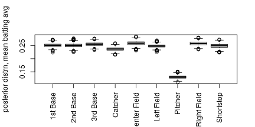

```r
gamma_samples <- rstan::extract(logistic_fit)$gamma
colnames(gamma_samples) <- levels(batplus$PriPos)
mu_samples <- 1/(1+exp(-gamma_samples))
boxplot(mu_samples, ylab="posterior distrn, mean batting avg", las=3)
```

## No effect of height or weight

```
## ci_level: 0.8 (80% intervals)
```

```
## outer_level: 0.95 (95% intervals)
```

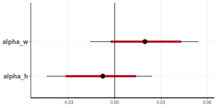

```r
stan_plot(logistic_fit, pars=c("alpha_w", "alpha_h")) + geom_vline(xintercept=0)
```

## Same $\theta$ as before?

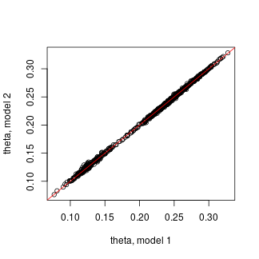

```r
new_post_theta <- colMeans(rstan::extract(logistic_fit)$theta)
old_post_theta <- batting$post_mean[match(batplus$Player, batting$Player)]
plot(old_post_theta, new_post_theta, xlab="theta, model 1", ylab="theta, model 2")
abline(0,1, col='red')
```

## Conclusions

1. We don’t have good evidence that batting average varies substantially with height or weight.
2. Changing the model from a Beta prior on class means to a logistic transform of a linear model did not substantially affect the results.

# Stochastic minute

If $X \sim \Cauchy(\text{center}=\mu, \text{scale}=\sigma)$, then $X$ has probability density
$$\begin{aligned}
f(x \given \mu, \sigma) = \frac{1}{\pi\left( 1 + \left( \frac{x - \mu}{\sigma} \right)^2 \right)} .
\end{aligned}$$

> 1. The Cauchy is a good example of a distribution with “heavy tails”: rare, very large values.
> 2. If $Y$ and $Z$ are independent $\Normal(0,1)$ then $Y/Z \sim \Cauchy(0,1)$.
> 3. If $\tau$ is $\Gam(1/2, 1/2)$ and $X$ is $\Normal(0, 1/\sqrt{\tau})$, then $X \sim \Cauchy(0,1)$.
> 4. If $X_1, X_2, \ldots, X_n$ are independent $\Cauchy(0,1)$ then $\max(X_1, \ldots, X_n)$ is of size $n$.

Also,

5. If $X_1, X_2, \ldots, X_n$ are independent $\Cauchy(0,1)$ then
   $$\begin{aligned}
   \frac{1}{n} \left(X_1 + \cdots + X_n\right) \sim \Cauchy(0,1) .
   \end{aligned}$$

*Wait, what?!?*

A single value has the *same distribution* as the mean of 1,000 of them?

Let’s look:

```r
meanplot <- function (rf, n=1e3, m=100) {
    x <- matrix(rf(n*m), ncol=m)
    layout(t(1:2))
    hist(x[1,][abs(x[1,])<5], breaks=20, freq=FALSE,
         main=sprintf("%d samples", m),
         xlim=c(-5,5))
    hist(colMeans(x)[abs(colMeans(x))<5], breaks=20, freq=FALSE,
         main=sprintf("%d means of %d each", m, n),
         xlim=c(-5,5))
}
```

$X \sim \Normal(0,1)$

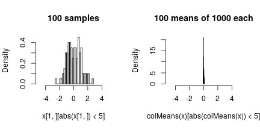

```r
meanplot(rnorm)
```

$X \sim \Cauchy(0,1)$

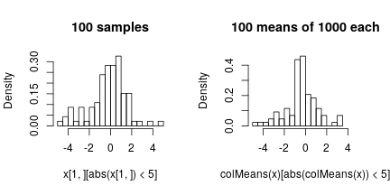

```r
meanplot(rcauchy)
```

## Another way to look at it: extreme values

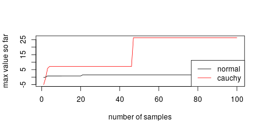

```r
n <- 100
plot(c(cummax(rcauchy(n))), type='l', ylab='max value so far', xlab='number of samples', col='red')
lines(c(cummax(rnorm(n))), col='black')
legend("bottomright", lty=1, col=c('black', 'red'), legend=c('normal', 'cauchy'))
```

## Another way to look at it: extreme values

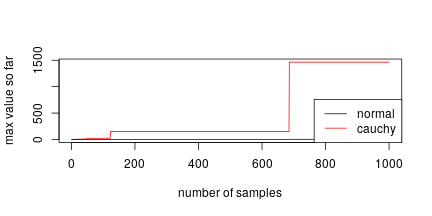

```r
n <- 1000
plot(c(cummax(rcauchy(n))), type='l', ylab='max value so far', xlab='number of samples', col='red')
lines(c(cummax(rnorm(n))), col='black')
legend("bottomright", lty=1, col=c('black', 'red'), legend=c('normal', 'cauchy'))
```

## Another way to look at it: extreme values

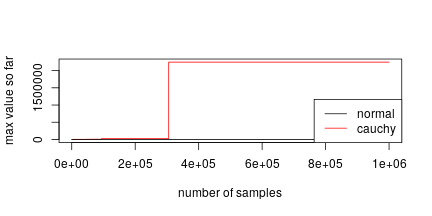

```r
n <- 1e6
plot(c(cummax(rcauchy(n))), type='l', ylab='max value so far', xlab='number of samples', col='red')
lines(c(cummax(rnorm(n))), col='black')
legend("bottomright", lty=1, col=c('black', 'red'), legend=c('normal', 'cauchy'))
```

# Robust regression

## Standard linear regression

$$\begin{aligned}
\hat y_i &= b_0 + b_1 x_i \\
y_i &\sim \Normal(\hat y_i, \sigma^2) .
\end{aligned}$$

Simulate data:

```r
truth <- list(b0=1.0, b1=2.0, sigma=0.5)
n <- 200
x <- rnorm(n, mean=0, sd=1)
y <- ( truth$b0 + truth$b1 * x
        + rnorm(n, mean=0, sd=truth$sigma) )
```

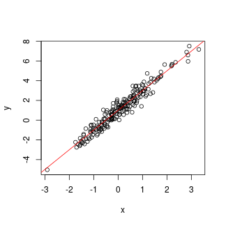

Standard linear regression

```r
system.time( slr <- lm(y ~ x) )
```

```
##    user  system elapsed
##   0.002   0.000   0.001
```

```r
summary(slr)
```

```
##
## Call:
## lm(formula = y ~ x)
##
## Residuals:
##      Min       1Q   Median       3Q      Max
## -1.50761 -0.35521 -0.00729  0.29981  1.35287
##
## Coefficients:
##             Estimate Std. Error t value Pr(>|t|)
## (Intercept)  0.97426    0.03689   26.41   <2e-16 ***
## x            2.02372    0.03610   56.05   <2e-16 ***
## ---
## Signif. codes:  0 '***' 0.001 '**' 0.01 '*' 0.05 '.' 0.1 ' ' 1
##
## Residual standard error: 0.5188 on 198 degrees of freedom
## Multiple R-squared:  0.9407, Adjusted R-squared:  0.9404
## F-statistic:  3142 on 1 and 198 DF,  p-value: < 2.2e-16
```

with Stan

```r
slr_block <- "
data {
    int N;
    vector[N] x;
    vector[N] y;
}
parameters {
    real b0;
    real b1;
    real<lower=0> sigma;
}
model {
    y ~ normal(b0 + b1*x, sigma);
}"
system.time( stanlr <- stan(model_code=slr_block,
                            data=list(N=length(x), x=x, y=y), iter=1e3) )
```

```
##    user  system elapsed
##  38.349   1.095  43.525
```

```r
print(stanlr)
```

[output not shown]

## Cauchy noise?

Relative axon growth for neurons after $x$ hours:

```r
truth <- list(b0=1.0, b1=2.0, sigma=0.5)
n <- 200
x <- rnorm(n, mean=0, sd=1)
y <- ( truth$b0 + truth$b1 * x
        + rcauchy(n, location=0,
                  scale=truth$sigma) )
```

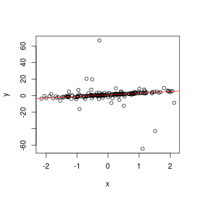

Standard linear regression

```r
system.time( slr2 <- lm(y ~ x) )
```

```
##    user  system elapsed
##   0.002   0.000   0.002
```

```r
summary(slr2)
```

```
##
## Call:
## lm(formula = y ~ x)
##
## Residuals:
##     Min      1Q  Median      3Q     Max
## -65.973  -0.877   0.120   1.312  66.074
##
## Coefficients:
##             Estimate Std. Error t value Pr(>|t|)
## (Intercept)   0.8918     0.5740   1.554    0.122
## x             0.7230     0.6172   1.171    0.243
##
## Residual standard error: 8.117 on 198 degrees of freedom
## Multiple R-squared:  0.006883,   Adjusted R-squared:  0.001868
## F-statistic: 1.372 on 1 and 198 DF,  p-value: 0.2428
```

with Stan

```r
srr_block <- "
data {
    int N;
    vector[N] x;
    vector[N] y;
}
parameters {
    real b0;
    real b1;
    real<lower=0> sigma;
}
model {
    y ~ cauchy(b0 + b1*x, sigma);
}"
system.time( stanrr <- stan(model_code=srr_block,
                            data=list(N=length(x), x=x, y=y), iter=1e3) )
```

```
##    user  system elapsed
##  39.552   1.132  44.817
```

```r
print(stanrr)
```

```
## Inference for Stan model: cd6e07d98bffcf77ad2b924fcd0f1723.
## 4 chains, each with iter=1000; warmup=500; thin=1;
## post-warmup draws per chain=500, total post-warmup draws=2000.
##
##          mean se_mean   sd    2.5%     25%     50%     75%   97.5% n_eff
## b0       1.00    0.00 0.04    0.92    0.97    1.00    1.03    1.09  1742
## b1       3.01    0.00 0.01    2.98    3.00    3.01    3.02    3.03  1918
## sigma    0.46    0.00 0.05    0.38    0.43    0.46    0.49    0.55  1598
## lp__  -114.57    0.03 1.16 -117.51 -115.13 -114.32 -113.70 -113.14  1186
##       Rhat
## b0       1
## b1       1
## sigma    1
## lp__     1
##
## Samples were drawn using NUTS(diag_e) at Wed Nov 28 15:48:39 2018.
## For each parameter, n_eff is a crude measure of effective sample size,
## and Rhat is the potential scale reduction factor on split chains (at
## convergence, Rhat=1).
```

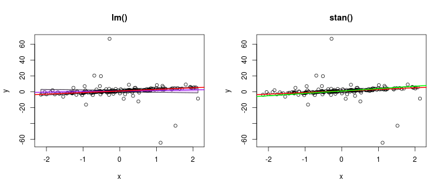

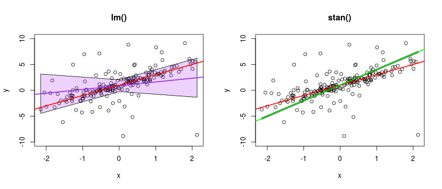

# Wrap-up

## Modeling, and Stan

1. How well a statistical method works depends on the situation.
2. We can describe the “situation” with a *probability model*.
3. Inference usually works best if the probabilistic model reflects reality .
4. Stan lets you do inference using (almost) arbitrary models.
5. Explicit models make it easy to simulate, and therefore test your methods.

## Hierarchical Bayesian models

1. It is often possible to infer things about *populations* that we can’t infer about individuals.
2. Doing so leads to *sharing of information* (or, “power”) between samples, and can improve accuracy.
3. Priors (and hyperpriors) on individual parameters provides a good way to do this.